# Logistic Regression

Author

Brileigh Cates

Logistic regression is a classification method used to model the probability that a binary outcome occurs, based on one or more predictor variables. Unlike linear regression, which predicts continuous values, logistic regression uses the logistic (sigmoid) function to constrain predictions between 0 and 1. It assumes a linear relationship between the predictors and the log-odds of the outcome. Logistic regression is widely used because it:

- Produces interpretable coefficients that indicate the direction and strength of association
- Works well with smaller datasets and fewer predictors
- Allows for statistical testing of individual variables’ significance

## Setting Up the Environment

### Loading the Data

```r
analysis_data <- readRDS(here("models","data","analysis_data.rds"))
analysis_train <- readRDS(here("models","data","analysis_train.rds"))
```

## Data Preprocessing

Before fitting our model, we need to preprocess the data. We’ll create a recipe that: - Imputes missing values in categorical variables using the mode - Imputes missing values in numeric variables using the mean - Removes predictors with zero variance - Removes highly correlated predictors (correlation threshold = 0.7)

```r
weapon_carry_recipe <-
  recipe(formula = WeaponCarryingSchool ~ ., data = analysis_data) %>%
  step_impute_mode(all_nominal_predictors()) %>%
  step_impute_mean(all_numeric_predictors()) %>%
  step_zv(all_predictors()) %>%
  step_corr(all_numeric_predictors(), threshold = 0.7)

weapon_carry_recipe
```

```
── Recipe ──────────────────────────────────────────────────────────────────────
```

```
── Inputs
```

```
Number of variables by role
```

```
outcome:    1
predictor: 10
```

```
── Operations
```

```
• Mode imputation for: all_nominal_predictors()
```

```
• Mean imputation for: all_numeric_predictors()
```

```
• Zero variance filter on: all_predictors()
```

```
• Correlation filter on: all_numeric_predictors()
```

Let’s apply our recipe to transform the data according to these preprocessing steps.

```r
rec <- weapon_carry_recipe %>%
  prep() %>%
  bake(new_data = analysis_data) %>%
  glimpse()
```

```
Rows: 19,595
Columns: 11
$ AttackedInNeighborhood   <fct> 0, 0, 0, 0, 0, 1, 0, 0, 0, 0, 0, 0, 1, 0, 0, …
$ Bullying                 <fct> 0, 1, 0, 0, 0, 0, 0, 0, 0, 0, 0, 0, 0, 0, 0, …
$ SexualAbuseByOlderPerson <fct> 0, 0, 0, 1, 0, 0, 0, 0, 0, 0, 1, 0, 0, 0, 0, …
$ ParentalPhysicalAbuse    <fct> 0, 0, 0, 0, 0, 1, 0, 0, 0, 0, 0, 0, 0, 0, 0, …
$ ParentSubstanceUse       <fct> 1, 1, 1, 1, 1, 1, 1, 1, 1, 1, 0, 1, 1, 1, 1, …
$ ParentIncarceration      <fct> 1, 1, 0, 1, 1, 1, 1, 1, 1, 1, 1, 1, 1, 1, 1, …
$ SchoolConnectedness      <fct> 1, 0, 0, 1, 0, 0, 1, 1, 1, 1, 0, 1, 0, 1, 0, …
$ ParentalMonitoring       <fct> 1, 0, 0, 0, 0, 0, 1, 1, 0, 0, 0, 0, 0, 1, 0, …
$ UnfairDisciplineAtSchool <fct> 1, 1, 1, 1, 1, 0, 1, 1, 1, 1, 1, 1, 1, 1, 1, …
$ Homelessness             <fct> 0, 0, 0, 0, 0, 0, 0, 0, 0, 0, 0, 0, 0, 0, 0, …
$ WeaponCarryingSchool     <fct> 0, 0, 0, 0, 0, 0, 0, 0, 0, 0, 0, 0, 0, 0, 0, …
```

## Model Specification

We’ll use a standard logistic regression model to predict a binary outcome. Logistic regression models the log-odds of the outcome as a linear combination of the predictors. It does not include any form of regularization by default, so all predictors are retained unless manually excluded. This makes it a good baseline model for interpreting how individual features relate to the outcome. We’ll include all relevant predictors and assess their individual contributions to the likelihood of weapon carrying.

```r
weapon_carry_spec <-
  logistic_reg() %>%
  set_mode("classification") %>%
  set_engine("glm")

weapon_carry_spec
```

```
Logistic Regression Model Specification (classification)

Computational engine: glm
```

## Creating the Workflow

We’ll combine our recipe and model specification into a single workflow. This ensures that all preprocessing steps are properly applied during both training and prediction.

```r
weapon_carry_workflow <- workflow() %>%
  add_recipe(weapon_carry_recipe) %>%
  add_model(weapon_carry_spec)

weapon_carry_workflow
```

```
══ Workflow ════════════════════════════════════════════════════════════════════
Preprocessor: Recipe
Model: logistic_reg()

── Preprocessor ────────────────────────────────────────────────────────────────
4 Recipe Steps

• step_impute_mode()
• step_impute_mean()
• step_zv()
• step_corr()

── Model ───────────────────────────────────────────────────────────────────────
Logistic Regression Model Specification (classification)

Computational engine: glm
```

## Fitting the Final Model

We’ll fit our final model on the training data. This process is also time-consuming, so we’ll save the results.

```r
mod1 <-
  fit(weapon_carry_workflow, data = analysis_train)

mod1
```

```
══ Workflow [trained] ══════════════════════════════════════════════════════════
Preprocessor: Recipe
Model: logistic_reg()

── Preprocessor ────────────────────────────────────────────────────────────────
4 Recipe Steps

• step_impute_mode()
• step_impute_mean()
• step_zv()
• step_corr()

── Model ───────────────────────────────────────────────────────────────────────

Call:  stats::glm(formula = ..y ~ ., family = stats::binomial, data = data)

Coefficients:
              (Intercept)    AttackedInNeighborhood1
                 -3.29938                    0.74950
                Bullying1  SexualAbuseByOlderPerson1
                  0.48405                    0.46540
   ParentalPhysicalAbuse1        ParentSubstanceUse1
                  0.71713                   -0.15917
     ParentIncarceration1       SchoolConnectedness1
                  0.07048                   -0.25542
      ParentalMonitoring1  UnfairDisciplineAtSchool1
                  0.59860                   -0.24268
            Homelessness1
                  1.18053

Degrees of Freedom: 14695 Total (i.e. Null);  14685 Residual
Null Deviance:      5238
Residual Deviance: 4872     AIC: 4894
```

```r
saveRDS(mod1, here("models","model_outputs","logistic_fit.rds"))
```

```r
tidy_model <-
  mod1 %>%
  tidy(exponentiate = TRUE,
       conf.int = TRUE,
       conf.level = 0.95) %>%
  mutate(p.value = scales::pvalue(p.value))

tidy_model
```

```
# A tibble: 11 × 7
   term                  estimate std.error statistic p.value conf.low conf.high
   <chr>                    <dbl>     <dbl>     <dbl> <chr>      <dbl>     <dbl>
 1 (Intercept)             0.0369    0.166    -19.9   <0.001    0.0266    0.0508
 2 AttackedInNeighborho…   2.12      0.0954     7.85  <0.001    1.75      2.55
 3 Bullying1               1.62      0.0919     5.27  <0.001    1.35      1.94
 4 SexualAbuseByOlderPe…   1.59      0.133      3.51  <0.001    1.22      2.06
 5 ParentalPhysicalAbus…   2.05      0.179      4.01  <0.001    1.43      2.89
 6 ParentSubstanceUse1     0.853     0.111     -1.44  0.151     0.688     1.06
 7 ParentIncarceration1    1.07      0.126      0.560 0.575     0.841     1.38
 8 SchoolConnectedness1    0.775     0.0970    -2.63  0.008     0.639     0.935
 9 ParentalMonitoring1     1.82      0.114      5.26  <0.001    1.45      2.27
10 UnfairDisciplineAtSc…   0.785     0.114     -2.13  0.033     0.629     0.984
11 Homelessness1           3.26      0.155      7.61  <0.001    2.39      4.39
```

```r
saveRDS(tidy_model, here("models","model_outputs", "logistic_tidy_fit.rds"))
```

## Model Evaluation

Let’s examine the model’s predictions on the training data.

```r
weapon_pred_logistic <-
  augment(mod1, analysis_train) %>%
  select(WeaponCarryingSchool, .pred_class, .pred_1, .pred_0)

weapon_pred_logistic
```

```
# A tibble: 14,696 × 4
   WeaponCarryingSchool .pred_class .pred_1 .pred_0
   <fct>                <fct>         <dbl>   <dbl>
 1 0                    0            0.0360   0.964
 2 0                    0            0.0412   0.959
 3 0                    0            0.0241   0.976
 4 0                    0            0.0317   0.968
 5 0                    0            0.128    0.872
 6 0                    0            0.0360   0.964
 7 0                    0            0.0201   0.980
 8 0                    0            0.0201   0.980
 9 0                    0            0.0471   0.953
10 0                    0            0.0531   0.947
# ℹ 14,686 more rows
```

We can visualize the model’s performance using a confusion matrix.

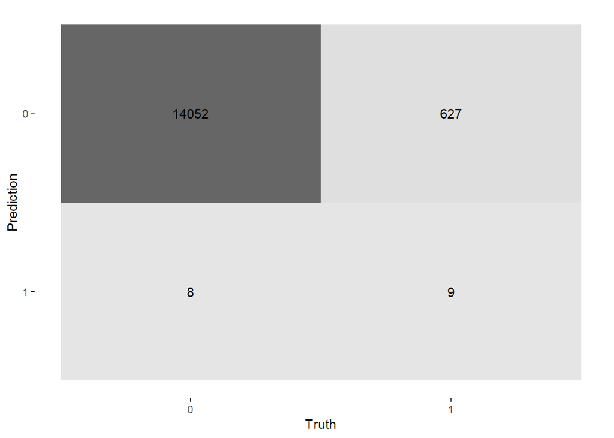

```r
weapon_pred_logistic %>%
  conf_mat(WeaponCarryingSchool, .pred_class) %>%
  autoplot(type = "heatmap")
```

We can visualize the model’s performance using an ROC curve.

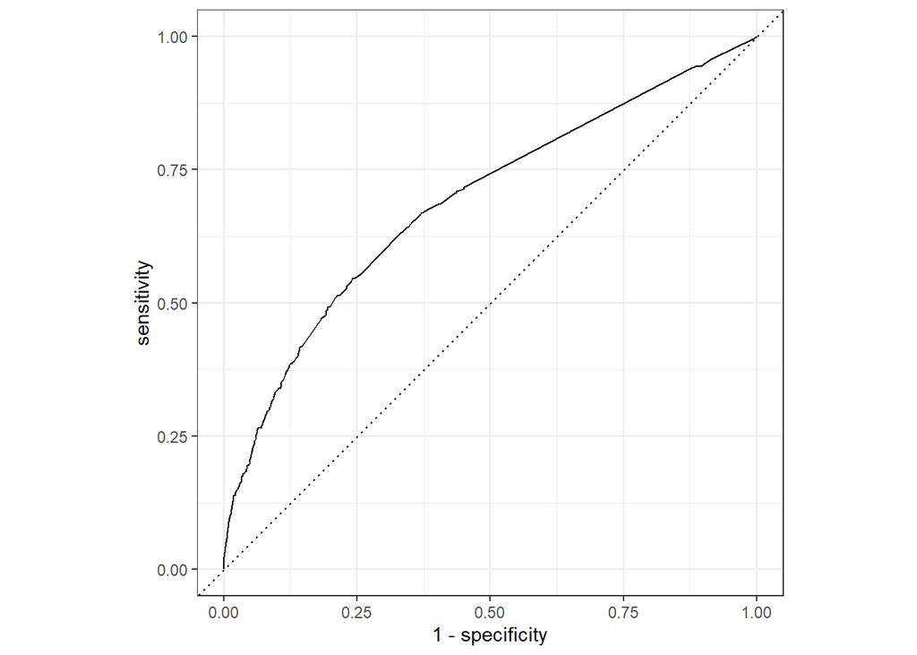

```r
roc_plot_logistic <-
  weapon_pred_logistic %>%
  roc_curve(truth = WeaponCarryingSchool, .pred_1, event_level = "second") %>%
  autoplot()


saveRDS(roc_plot_logistic, here("models","roc_graphs", "logistic.rds"))

roc_plot_logistic
```